# Initial ARTs Results

Sarah P. Flanagan

01 August, 2018

The purpose of this model is to understand how genetic architectures of alternative reproductive tactics impact their maintenance in populations. I’m using an individual-based simulation model with different selection scenarios, types of alternative tactics, and genetic architectures (genome-wide additive genetic variance, supergenes, expression networks) To test the model and make sure that everything has been implemented correctly, I’m first testing to ensure that the model produces the expected results without the genetic architectures.

## Overview of the model

Males can be courters or not-courters and parents or not-parents. When the model is run with both traits, this results in four possible morphs: courter/parent, courter/not-parent, not-courter/parent, and not-courter/not-parent. Generations are non-overlapping and there is one reproductive bout per generation. In each generation, the population follows the following timeline:

1. Females choose a nest
2. Males fertilize eggs
3. Nests survive or die
4. Viability selection on progeny
5. Stochastic survival to adulthood

### 1. Choosing a nest

A female samples 50 males and chooses a male to nest with based on his courtship trait. If there are no courtship traits in the model, she chooses based on the male’s parental trait. If she does not encouter an acceptable male, she does not nest. If she encounters multiple equally-acceptable males, she randomly selects one of them.

### 2. Fertilization

Once a female decides to nest, up to three males can fertilize the nest. Courters and parental males can contribute more sperm than non-courter and non-parental males: $r_{courter}=r_{parent}=8$ and $r_{non-courter}=r_{non-parent}=4$. A courter/non-parent has $r_{non-parent}$ and a non-courter/parent has $r_{parent}$. The male with whom the female is nesting gets $r_{parent}/\Sigma{n_{sperm}}$ and additional non-parental males (up to 2) get $(r_{non-parent}*0.5/\Sigma{n_{sperm}})$, where $\Sigma{n_{sperm}}$ is the total number of sperm contributed by all of the males, weighted by the sperm competition factor (0.5 is the default for all males except the nesting male). So, when a female mates with one courter and two non-parentals, $\Sigma{n_{sperm}}$ = $r_{courter}$ + 2$*$(0.5$*$$r_{sneaker}$), where $r_{courter}$ = 8 and $r_{sneaker}$ = 4, therefore $\Sigma{n_{sperm}}$ = 12.

That being said, every time a male mates he uses his sperm, so after one mating where a courter fertilizes 50% of the female’s 4 eggs, he only has 6 sperm for his next mating.

### 3. Nest Survival

Before the babies can survive, the nest has to survive. This step is only relevant when parental traits are in the model - if only the courtship trait is specified, then all progeny in the nest survive at this point. When males have the parental trait, if the female has given eggs to a non-parental male (because she chose based on courtship traits), then the nest has a 10% chance of surviving. If the female has given eggs to a parental male, the nest has a 90% chance of surviving.

### 4. Viability selection and 5. Stochastic survival

Then the offspring experience viability selection. Courters and parental males are disfavored in viability selection, with a survival probability of 0.9950125. If an individual is both a courter and a parental male, the survival probability is 0.9900498. Non-courters and non-parental males have survival probabilities of 1. Once viability selection has been imposed, individuals die or survive randomly, and the next generation gets a chance to mate.

### Evaluating equilibrium

After 10000 generations, I begin tracking the change in frequency of the courter and parent traits, and do so for 2000 additional generations. I calculate the variance in the change in frequency over those 2000 generations. I declare an equilibrium (‘stasis’) has been reached if the last change in frequency of both traits is less than the variance in changes in frequency.

## Unlinked additive genetic variance

In these cases, the traits are encoded by a number (50) of loci, whose alleles contribute additively to determine the trait value. These alleles are all freely recombining and are not adhered to any physical genomic location (aka this is a classical quantitative genetics approach). The overall trait value is compared to a population-level threshold (which is static, in these cases), and if the trait value is above the threshold the male takes the parent or courter morph and if it is below he does not. Below, I’m showing the results from 10 replicates of each scenario.

### Courter trait

Females choose nests based on whether the male is a courter or not, and they all prefer courters all of the time (the female preference does not have a genetic basis and does not evolve). The only way that non-courters produce offspring is through sneaking, but all males can be sneakers (both courters and non-courters). Because parental care is not incorporated in this model, all nests survive.

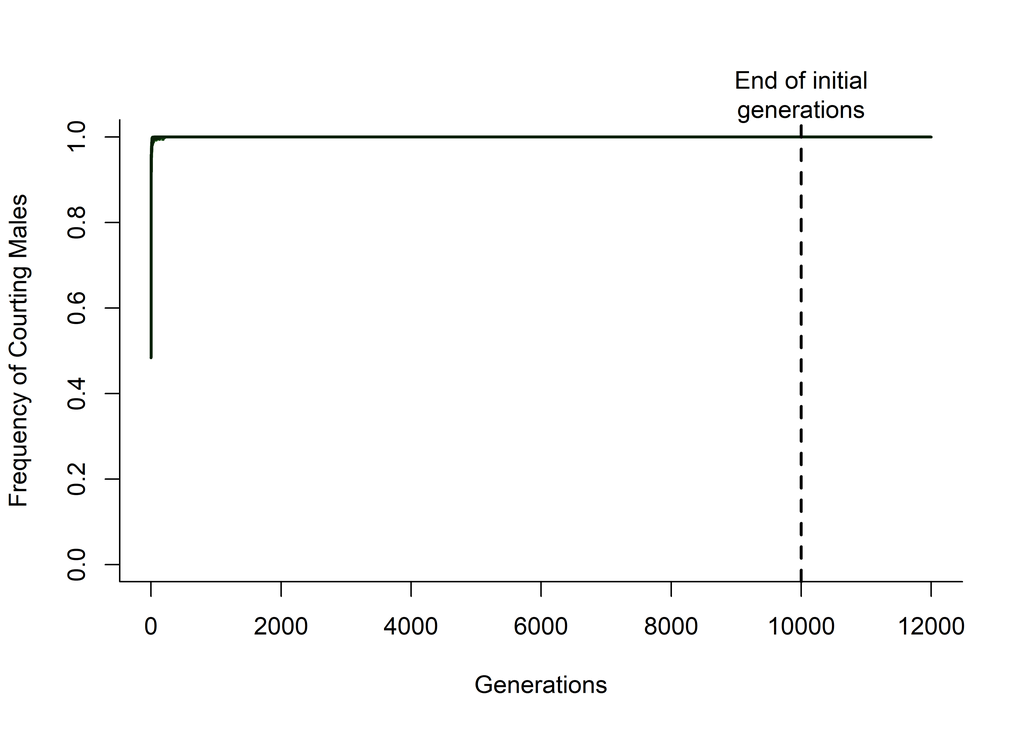

Frequency of the courter morph (each color represents a different replicate)

Frequency of courters in final generation

|  | CourterFreq | CourterW | NonCourterW |
| --- | --- | --- | --- |
| courter-nogenetics_1_summary.txt_1 | 1 | 3.32365 | 0 |
| courter-nogenetics_1_summary.txt_2 | 1 | 2.83647 | 0 |
| courter-nogenetics_1_summary.txt_3 | 1 | 3.18384 | 0 |
| courter-nogenetics_1_summary.txt_4 | 1 | 2.73358 | 0 |
| courter-nogenetics_10_summary.txt_1 | 1 | 3.32365 | 0 |
| courter-nogenetics_10_summary.txt_2 | 1 | 2.83647 | 0 |
| courter-nogenetics_10_summary.txt_3 | 1 | 3.18384 | 0 |
| courter-nogenetics_10_summary.txt_4 | 1 | 2.73358 | 0 |
| courter-nogenetics_2_summary.txt_1 | 1 | 3.32365 | 0 |
| courter-nogenetics_2_summary.txt_2 | 1 | 2.83647 | 0 |
| courter-nogenetics_2_summary.txt_3 | 1 | 3.18384 | 0 |
| courter-nogenetics_2_summary.txt_4 | 1 | 2.73358 | 0 |
| courter-nogenetics_3_summary.txt_1 | 1 | 3.32365 | 0 |
| courter-nogenetics_3_summary.txt_2 | 1 | 2.83647 | 0 |
| courter-nogenetics_3_summary.txt_3 | 1 | 3.18384 | 0 |
| courter-nogenetics_3_summary.txt_4 | 1 | 2.73358 | 0 |
| courter-nogenetics_4_summary.txt_1 | 1 | 3.32365 | 0 |
| courter-nogenetics_4_summary.txt_2 | 1 | 2.83647 | 0 |
| courter-nogenetics_4_summary.txt_3 | 1 | 3.18384 | 0 |
| courter-nogenetics_4_summary.txt_4 | 1 | 2.73358 | 0 |
| courter-nogenetics_5_summary.txt_1 | 1 | 2.90734 | 0 |
| courter-nogenetics_5_summary.txt_2 | 1 | 3.28310 | 0 |
| courter-nogenetics_5_summary.txt_3 | 1 | 2.99610 | 0 |
| courter-nogenetics_5_summary.txt_4 | 1 | 2.90857 | 0 |
| courter-nogenetics_6_summary.txt_1 | 1 | 3.32365 | 0 |
| courter-nogenetics_6_summary.txt_2 | 1 | 2.83647 | 0 |
| courter-nogenetics_6_summary.txt_3 | 1 | 3.18384 | 0 |
| courter-nogenetics_6_summary.txt_4 | 1 | 2.73358 | 0 |
| courter-nogenetics_7_summary.txt_1 | 1 | 2.90734 | 0 |
| courter-nogenetics_7_summary.txt_2 | 1 | 3.28310 | 0 |
| courter-nogenetics_7_summary.txt_3 | 1 | 2.99610 | 0 |
| courter-nogenetics_7_summary.txt_4 | 1 | 2.90857 | 0 |
| courter-nogenetics_8_summary.txt_1 | 1 | 3.32365 | 0 |
| courter-nogenetics_8_summary.txt_2 | 1 | 2.83647 | 0 |
| courter-nogenetics_8_summary.txt_3 | 1 | 3.18384 | 0 |
| courter-nogenetics_8_summary.txt_4 | 1 | 2.73358 | 0 |
| courter-nogenetics_9_summary.txt_1 | 1 | 3.32365 | 0 |
| courter-nogenetics_9_summary.txt_2 | 1 | 2.83647 | 0 |
| courter-nogenetics_9_summary.txt_3 | 1 | 3.18384 | 0 |
| courter-nogenetics_9_summary.txt_4 | 1 | 2.73358 | 0 |

### Parental trait

All females nest with parental males, so the only way non-parental males reproduce is through sneaking. Parental males provide care that allows nests to have a 90% chance of survival. The female preference does not have a genetic basis and does not evolve.

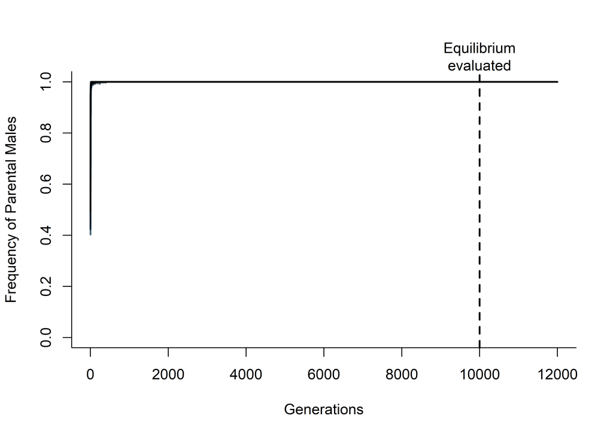

Frequency of parent morph (each color represents a different replicate)

Frequency of parents in final generation

|  | ParentFreq | ParentW | NonParentW |
| --- | --- | --- | --- |
| parent-nogenetics_1_summary.txt_1 | 1 | 3.57948 | 0 |
| parent-nogenetics_1_summary.txt_2 | 1 | 3.55489 | 0 |
| parent-nogenetics_1_summary.txt_3 | 1 | 3.63158 | 0 |
| parent-nogenetics_1_summary.txt_4 | 1 | 3.31489 | 0 |
| parent-nogenetics_10_summary.txt_1 | 1 | 3.32302 | 0 |
| parent-nogenetics_10_summary.txt_2 | 1 | 3.53119 | 0 |
| parent-nogenetics_10_summary.txt_3 | 1 | 3.57531 | 0 |
| parent-nogenetics_10_summary.txt_4 | 1 | 3.50731 | 0 |
| parent-nogenetics_2_summary.txt_1 | 1 | 3.58316 | 0 |
| parent-nogenetics_2_summary.txt_2 | 1 | 3.33398 | 0 |
| parent-nogenetics_2_summary.txt_3 | 1 | 3.58859 | 0 |
| parent-nogenetics_2_summary.txt_4 | 1 | 3.41602 | 0 |
| parent-nogenetics_3_summary.txt_1 | 1 | 3.51205 | 0 |
| parent-nogenetics_3_summary.txt_2 | 1 | 3.46863 | 0 |
| parent-nogenetics_3_summary.txt_3 | 1 | 3.40900 | 0 |
| parent-nogenetics_3_summary.txt_4 | 1 | 3.36944 | 0 |
| parent-nogenetics_4_summary.txt_1 | 1 | 3.58656 | 0 |
| parent-nogenetics_4_summary.txt_2 | 1 | 3.56495 | 0 |
| parent-nogenetics_4_summary.txt_3 | 1 | 3.18631 | 0 |
| parent-nogenetics_4_summary.txt_4 | 1 | 3.38327 | 0 |
| parent-nogenetics_5_summary.txt_1 | 1 | 3.58683 | 0 |
| parent-nogenetics_5_summary.txt_2 | 1 | 3.60606 | 0 |
| parent-nogenetics_5_summary.txt_3 | 1 | 3.29808 | 0 |
| parent-nogenetics_5_summary.txt_4 | 1 | 3.49008 | 0 |
| parent-nogenetics_6_summary.txt_1 | 1 | 3.57948 | 0 |
| parent-nogenetics_6_summary.txt_2 | 1 | 3.55489 | 0 |
| parent-nogenetics_6_summary.txt_3 | 1 | 3.63158 | 0 |
| parent-nogenetics_6_summary.txt_4 | 1 | 3.31489 | 0 |
| parent-nogenetics_7_summary.txt_1 | 1 | 3.54672 | 0 |
| parent-nogenetics_7_summary.txt_2 | 1 | 3.55888 | 0 |
| parent-nogenetics_7_summary.txt_3 | 1 | 3.47255 | 0 |
| parent-nogenetics_7_summary.txt_4 | 1 | 3.47714 | 0 |
| parent-nogenetics_8_summary.txt_1 | 1 | 3.38953 | 0 |
| parent-nogenetics_8_summary.txt_2 | 1 | 3.63320 | 0 |
| parent-nogenetics_8_summary.txt_3 | 1 | 3.30651 | 0 |
| parent-nogenetics_8_summary.txt_4 | 1 | 3.37137 | 0 |
| parent-nogenetics_9_summary.txt_1 | 1 | 3.54435 | 0 |
| parent-nogenetics_9_summary.txt_2 | 1 | 3.53373 | 0 |
| parent-nogenetics_9_summary.txt_3 | 1 | 3.37938 | 0 |
| parent-nogenetics_9_summary.txt_4 | 1 | 3.40157 | 0 |

### Courtship and Parental Traits

Females choose nests based on males’ courtship trait (they all only nest with courting males, and the female preference does not have a genetic basis and does not evolve), and then the survival of the nest depends on whether the courting male is also a parental male. If the chosen male is a parental male, the nest has a 90% chance of survival. Otherwise, it only has a 10% chance. Non-courters only reproduce through sneaking.

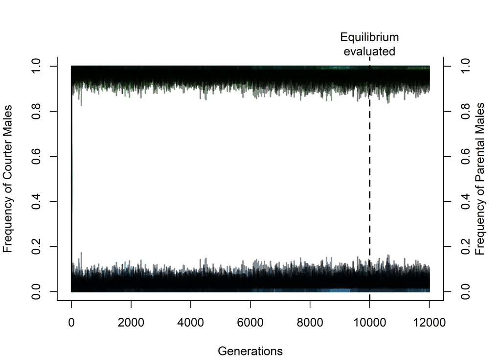

The different runs have different outcomes.

Let’s look at the morph frequencies.

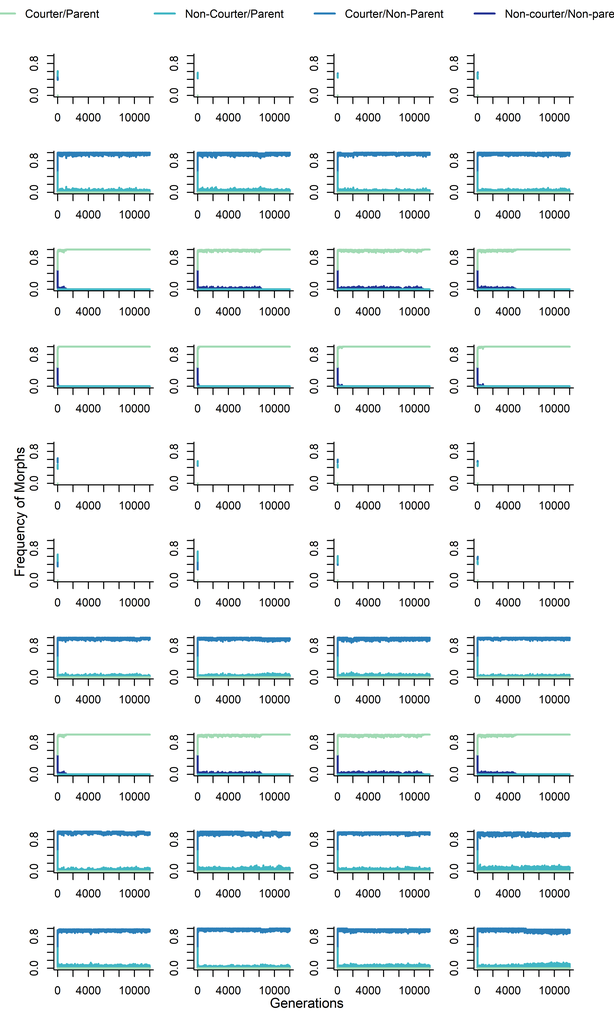

Frequency of the 4 morphs in each rep

In some of the runs the population crashed after few generations. This is obvious when looking at the the final frequencies in a table as well:

Frequency of morphs in final generation

|  | Generation | FreqNcNp | FreqCNp | FreqNcP | FreqCP |
| --- | --- | --- | --- | --- | --- |
| parent-courter-nogenetics_1_summary.txt_1 | 14 | 0 | 0.428571 | 0.5714290 | 0 |
| parent-courter-nogenetics_1_summary.txt_2 | 14 | 0 | 0.520000 | 0.4800000 | 0 |
| parent-courter-nogenetics_1_summary.txt_3 | 14 | 0 | 0.522727 | 0.4772730 | 0 |
| parent-courter-nogenetics_1_summary.txt_4 | 14 | 0 | 0.548387 | 0.4516130 | 0 |
| parent-courter-nogenetics_10_summary.txt_1 | 11999 | 0 | 0.979167 | 0.0208333 | 0 |
| parent-courter-nogenetics_10_summary.txt_2 | 11999 | 0 | 0.978723 | 0.0212766 | 0 |
| parent-courter-nogenetics_10_summary.txt_3 | 11999 | 0 | 0.980769 | 0.0192308 | 0 |
| parent-courter-nogenetics_10_summary.txt_4 | 11999 | 0 | 0.979592 | 0.0204082 | 0 |
| parent-courter-nogenetics_2_summary.txt_1 | 11999 | 0 | 0.000000 | 0.0000000 | 1 |
| parent-courter-nogenetics_2_summary.txt_2 | 11999 | 0 | 0.000000 | 0.0000000 | 1 |
| parent-courter-nogenetics_2_summary.txt_3 | 11999 | 0 | 0.000000 | 0.0000000 | 1 |
| parent-courter-nogenetics_2_summary.txt_4 | 11999 | 0 | 0.000000 | 0.0000000 | 1 |
| parent-courter-nogenetics_3_summary.txt_1 | 11999 | 0 | 0.000000 | 0.0000000 | 1 |
| parent-courter-nogenetics_3_summary.txt_2 | 11999 | 0 | 0.000000 | 0.0000000 | 1 |
| parent-courter-nogenetics_3_summary.txt_3 | 11999 | 0 | 0.000000 | 0.0000000 | 1 |
| parent-courter-nogenetics_3_summary.txt_4 | 11999 | 0 | 0.000000 | 0.0000000 | 1 |
| parent-courter-nogenetics_4_summary.txt_1 | 10 | 0 | 0.636364 | 0.3636360 | 0 |
| parent-courter-nogenetics_4_summary.txt_2 | 9 | 0 | 0.440000 | 0.5600000 | 0 |
| parent-courter-nogenetics_4_summary.txt_3 | 9 | 0 | 0.561404 | 0.4385960 | 0 |
| parent-courter-nogenetics_4_summary.txt_4 | 9 | 0 | 0.486486 | 0.5135140 | 0 |
| parent-courter-nogenetics_5_summary.txt_1 | 10 | 0 | 0.347826 | 0.6521740 | 0 |
| parent-courter-nogenetics_5_summary.txt_2 | 10 | 0 | 0.500000 | 0.5000000 | 0 |
| parent-courter-nogenetics_5_summary.txt_3 | 10 | 0 | 0.521739 | 0.4782610 | 0 |
| parent-courter-nogenetics_5_summary.txt_4 | 10 | 0 | 0.562500 | 0.4375000 | 0 |
| parent-courter-nogenetics_6_summary.txt_1 | 11999 | 0 | 1.000000 | 0.0000000 | 0 |
| parent-courter-nogenetics_6_summary.txt_2 | 11999 | 0 | 0.947368 | 0.0526316 | 0 |
| parent-courter-nogenetics_6_summary.txt_3 | 11999 | 0 | 0.978261 | 0.0217391 | 0 |
| parent-courter-nogenetics_6_summary.txt_4 | 11999 | 0 | 0.983607 | 0.0163934 | 0 |
| parent-courter-nogenetics_7_summary.txt_1 | 11999 | 0 | 0.000000 | 0.0000000 | 1 |
| parent-courter-nogenetics_7_summary.txt_2 | 11999 | 0 | 0.000000 | 0.0000000 | 1 |
| parent-courter-nogenetics_7_summary.txt_3 | 11999 | 0 | 0.000000 | 0.0000000 | 1 |
| parent-courter-nogenetics_7_summary.txt_4 | 11999 | 0 | 0.000000 | 0.0000000 | 1 |
| parent-courter-nogenetics_8_summary.txt_1 | 11999 | 0 | 0.979167 | 0.0208333 | 0 |
| parent-courter-nogenetics_8_summary.txt_2 | 11999 | 0 | 0.936170 | 0.0638298 | 0 |
| parent-courter-nogenetics_8_summary.txt_3 | 11999 | 0 | 0.966102 | 0.0338983 | 0 |
| parent-courter-nogenetics_8_summary.txt_4 | 11999 | 0 | 0.921569 | 0.0784314 | 0 |
| parent-courter-nogenetics_9_summary.txt_1 | 11999 | 0 | 0.960000 | 0.0400000 | 0 |
| parent-courter-nogenetics_9_summary.txt_2 | 11999 | 0 | 0.983871 | 0.0161290 | 0 |
| parent-courter-nogenetics_9_summary.txt_3 | 11999 | 0 | 0.982456 | 0.0175439 | 0 |
| parent-courter-nogenetics_9_summary.txt_4 | 11999 | 0 | 0.970588 | 0.0294118 | 0 |

Multiple morphs are maintained in 27 of the 40 replicates, and those morphs contain either a parent or a courter. However, 12 of those reps with variation actually crashed.

### Courtship + Heritable Female Preferences

Here, the female preference has unlinked additive genetic variance that is inherited. The traits begin as uncorrelated and are not pleiotropic (i.e., they have different genes underlying them). A threshold is set in the first generation that determines the switch point for when females prefer courters or non-courters. This threshold does not change over the generations. All males can be sneakers, but the male who females choose to nest with get a first male advantage.

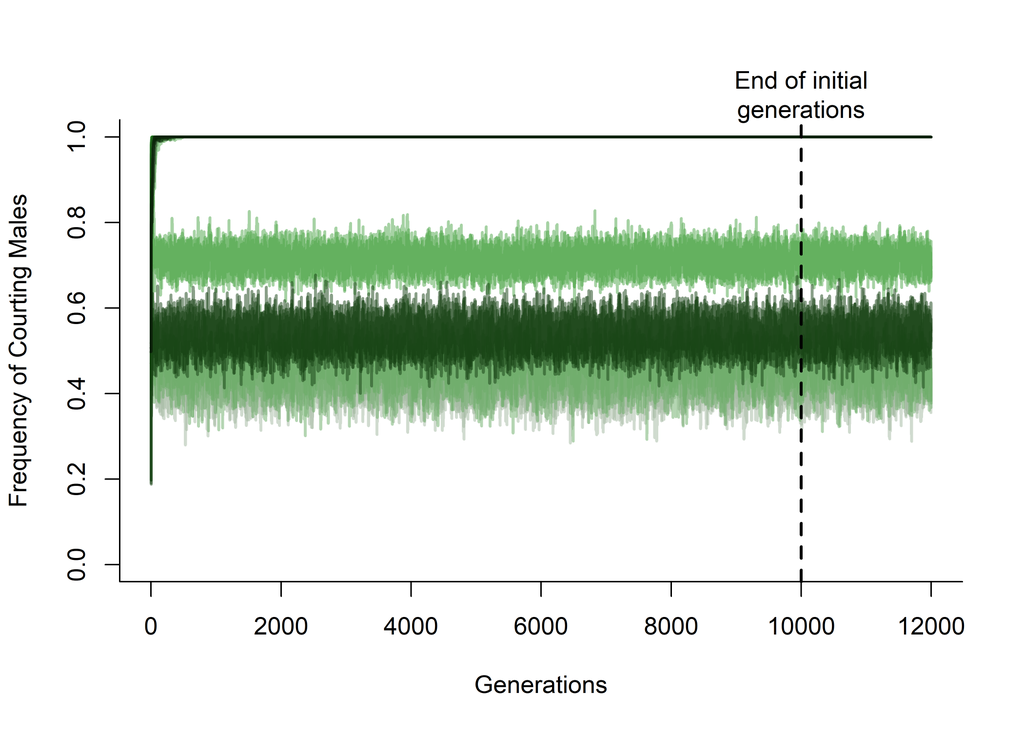

Courter frequencies

Courter Frequncies with heritable female preferences

|  | Generation | CourterFreq | CourterW | NonCourterW |
| --- | --- | --- | --- | --- |
| courter-pref-nogenetics_1_summary.txt_1 | 11999 | 0.434524 | 3.04110 | 3.00702 |
| courter-pref-nogenetics_1_summary.txt_2 | 11999 | 0.434125 | 3.99005 | 3.34733 |
| courter-pref-nogenetics_1_summary.txt_3 | 11999 | 0.410256 | 3.12981 | 3.03344 |
| courter-pref-nogenetics_1_summary.txt_4 | 11999 | 0.376894 | 2.63317 | 2.75380 |
| courter-pref-nogenetics_10_summary.txt_1 | 11999 | 1.000000 | 3.05917 | 0.00000 |
| courter-pref-nogenetics_10_summary.txt_2 | 11999 | 1.000000 | 3.01969 | 0.00000 |
| courter-pref-nogenetics_10_summary.txt_3 | 11999 | 1.000000 | 3.10558 | 0.00000 |
| courter-pref-nogenetics_10_summary.txt_4 | 11999 | 1.000000 | 3.24131 | 0.00000 |
| courter-pref-nogenetics_2_summary.txt_1 | 11999 | 1.000000 | 3.42767 | 0.00000 |
| courter-pref-nogenetics_2_summary.txt_2 | 11999 | 1.000000 | 3.13174 | 0.00000 |
| courter-pref-nogenetics_2_summary.txt_3 | 11999 | 1.000000 | 2.92816 | 0.00000 |
| courter-pref-nogenetics_2_summary.txt_4 | 11999 | 1.000000 | 3.34792 | 0.00000 |
| courter-pref-nogenetics_3_summary.txt_1 | 11999 | 0.380165 | 3.50543 | 3.15667 |
| courter-pref-nogenetics_3_summary.txt_2 | 11999 | 1.000000 | 2.98228 | 0.00000 |
| courter-pref-nogenetics_3_summary.txt_3 | 11999 | 0.413793 | 3.29412 | 3.19723 |
| courter-pref-nogenetics_3_summary.txt_4 | 11999 | 0.378049 | 3.37097 | 3.17974 |
| courter-pref-nogenetics_4_summary.txt_1 | 11999 | 0.697266 | 2.82913 | 2.83226 |
| courter-pref-nogenetics_4_summary.txt_2 | 11999 | 1.000000 | 2.86160 | 0.00000 |
| courter-pref-nogenetics_4_summary.txt_3 | 11999 | 0.674374 | 2.76571 | 2.72781 |
| courter-pref-nogenetics_4_summary.txt_4 | 11999 | 0.756148 | 3.17886 | 3.15966 |
| courter-pref-nogenetics_5_summary.txt_1 | 11999 | 1.000000 | 3.09761 | 0.00000 |
| courter-pref-nogenetics_5_summary.txt_2 | 11999 | 1.000000 | 3.09703 | 0.00000 |
| courter-pref-nogenetics_5_summary.txt_3 | 11999 | 1.000000 | 3.13095 | 0.00000 |
| courter-pref-nogenetics_5_summary.txt_4 | 11999 | 1.000000 | 3.19798 | 0.00000 |
| courter-pref-nogenetics_6_summary.txt_1 | 11999 | 1.000000 | 3.11706 | 0.00000 |
| courter-pref-nogenetics_6_summary.txt_2 | 11999 | 1.000000 | 3.04734 | 0.00000 |
| courter-pref-nogenetics_6_summary.txt_3 | 11999 | 1.000000 | 3.01375 | 0.00000 |
| courter-pref-nogenetics_6_summary.txt_4 | 11999 | 1.000000 | 3.05556 | 0.00000 |
| courter-pref-nogenetics_7_summary.txt_1 | 11999 | 1.000000 | 2.97656 | 0.00000 |
| courter-pref-nogenetics_7_summary.txt_2 | 11999 | 1.000000 | 3.08748 | 0.00000 |
| courter-pref-nogenetics_7_summary.txt_3 | 11999 | 1.000000 | 3.29569 | 0.00000 |
| courter-pref-nogenetics_7_summary.txt_4 | 11999 | 1.000000 | 3.35270 | 0.00000 |
| courter-pref-nogenetics_8_summary.txt_1 | 11999 | 0.574000 | 2.86063 | 3.10329 |
| courter-pref-nogenetics_8_summary.txt_2 | 11999 | 0.506667 | 2.71429 | 2.68340 |
| courter-pref-nogenetics_8_summary.txt_3 | 11999 | 0.548828 | 2.79359 | 3.06061 |
| courter-pref-nogenetics_8_summary.txt_4 | 11999 | 0.523232 | 3.08880 | 3.06780 |
| courter-pref-nogenetics_9_summary.txt_1 | 11999 | 1.000000 | 3.21818 | 0.00000 |
| courter-pref-nogenetics_9_summary.txt_2 | 11999 | 1.000000 | 3.15694 | 0.00000 |
| courter-pref-nogenetics_9_summary.txt_3 | 11999 | 1.000000 | 3.28041 | 0.00000 |
| courter-pref-nogenetics_9_summary.txt_4 | 11999 | 1.000000 | 2.88123 | 0.00000 |

Evolving female preferences allow variation to be maintained in 14 of 40 replicates.

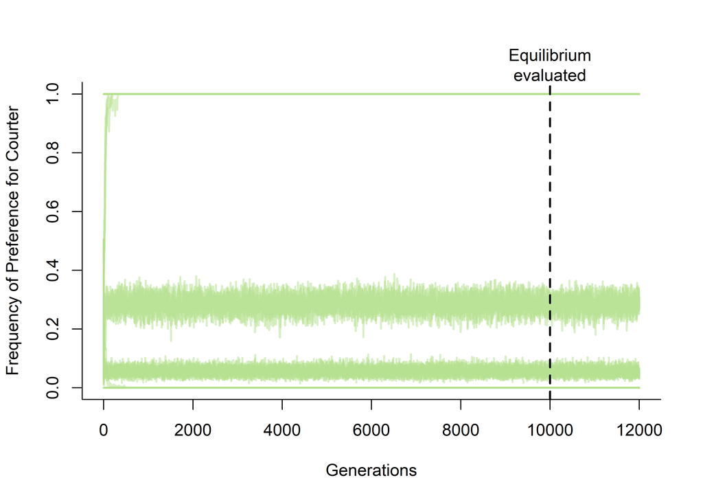

Frequencies of preferences for courters when parenting traits do not exist

Frequncies of Preference for Courters

|  | Generation | PrefFreq | PrefThresh |
| --- | --- | --- | --- |
| courter-pref-nogenetics_1_summary.txt_1 | 11999 | 0.0000000 | -0.1355290 |
| courter-pref-nogenetics_1_summary.txt_2 | 11999 | 0.0000000 | -0.1355290 |
| courter-pref-nogenetics_1_summary.txt_3 | 11999 | 0.0000000 | -0.1355290 |
| courter-pref-nogenetics_1_summary.txt_4 | 11999 | 0.0000000 | -0.1355290 |
| courter-pref-nogenetics_10_summary.txt_1 | 11999 | 1.0000000 | -0.0289756 |
| courter-pref-nogenetics_10_summary.txt_2 | 11999 | 1.0000000 | -0.0289756 |
| courter-pref-nogenetics_10_summary.txt_3 | 11999 | 1.0000000 | -0.0289756 |
| courter-pref-nogenetics_10_summary.txt_4 | 11999 | 1.0000000 | -0.0289756 |
| courter-pref-nogenetics_2_summary.txt_1 | 11999 | 1.0000000 | -0.4844860 |
| courter-pref-nogenetics_2_summary.txt_2 | 11999 | 1.0000000 | -0.4844860 |
| courter-pref-nogenetics_2_summary.txt_3 | 11999 | 1.0000000 | -0.4844860 |
| courter-pref-nogenetics_2_summary.txt_4 | 11999 | 1.0000000 | -0.4844860 |
| courter-pref-nogenetics_3_summary.txt_1 | 11999 | 0.0000000 | 0.7398050 |
| courter-pref-nogenetics_3_summary.txt_2 | 11999 | 0.0000000 | 0.7398050 |
| courter-pref-nogenetics_3_summary.txt_3 | 11999 | 0.0000000 | 0.7398050 |
| courter-pref-nogenetics_3_summary.txt_4 | 11999 | 0.0000000 | 0.7398050 |
| courter-pref-nogenetics_4_summary.txt_1 | 11999 | 0.2725410 | 0.5405090 |
| courter-pref-nogenetics_4_summary.txt_2 | 11999 | 0.0000000 | 0.5405090 |
| courter-pref-nogenetics_4_summary.txt_3 | 11999 | 0.2785860 | 0.5405090 |
| courter-pref-nogenetics_4_summary.txt_4 | 11999 | 0.2558590 | 0.5405090 |
| courter-pref-nogenetics_5_summary.txt_1 | 11999 | 1.0000000 | -0.3014470 |
| courter-pref-nogenetics_5_summary.txt_2 | 11999 | 1.0000000 | -0.3014470 |
| courter-pref-nogenetics_5_summary.txt_3 | 11999 | 1.0000000 | -0.3014470 |
| courter-pref-nogenetics_5_summary.txt_4 | 11999 | 1.0000000 | -0.3014470 |
| courter-pref-nogenetics_6_summary.txt_1 | 11999 | 1.0000000 | -0.8476090 |
| courter-pref-nogenetics_6_summary.txt_2 | 11999 | 1.0000000 | -0.8476090 |
| courter-pref-nogenetics_6_summary.txt_3 | 11999 | 1.0000000 | -0.8476090 |
| courter-pref-nogenetics_6_summary.txt_4 | 11999 | 1.0000000 | -0.8476090 |
| courter-pref-nogenetics_7_summary.txt_1 | 11999 | 1.0000000 | -0.1473850 |
| courter-pref-nogenetics_7_summary.txt_2 | 11999 | 1.0000000 | -0.1473850 |
| courter-pref-nogenetics_7_summary.txt_3 | 11999 | 1.0000000 | -0.1473850 |
| courter-pref-nogenetics_7_summary.txt_4 | 11999 | 1.0000000 | -0.1473850 |
| courter-pref-nogenetics_8_summary.txt_1 | 11999 | 0.0480000 | 0.7687990 |
| courter-pref-nogenetics_8_summary.txt_2 | 11999 | 0.0673684 | 0.7687990 |
| courter-pref-nogenetics_8_summary.txt_3 | 11999 | 0.0368852 | 0.7687990 |
| courter-pref-nogenetics_8_summary.txt_4 | 11999 | 0.0495050 | 0.7687990 |
| courter-pref-nogenetics_9_summary.txt_1 | 11999 | 1.0000000 | -0.2390990 |
| courter-pref-nogenetics_9_summary.txt_2 | 11999 | 1.0000000 | -0.2390990 |
| courter-pref-nogenetics_9_summary.txt_3 | 11999 | 1.0000000 | -0.2390990 |
| courter-pref-nogenetics_9_summary.txt_4 | 11999 | 1.0000000 | -0.2390990 |

Of the 40 populations that survived, 24 were fixed for a preference for courters and 9 were fixed for a preference against courters. 7 maintained variation in female preferences.

### Parenting + Heritable Female Preferences

Here, the female preference has unlinked additive genetic variance that is inherited. The traits begin as uncorrelated and are not pleiotropic (i.e., they have different genes underlying them). A threshold is set in the first generation that determines the switch point for when females prefer parents or non-parents. This threshold does not change over the generations. Only non-parental males can be sneakers, and when females choose to mate with non-parents, the nest has a 10% survival rate.

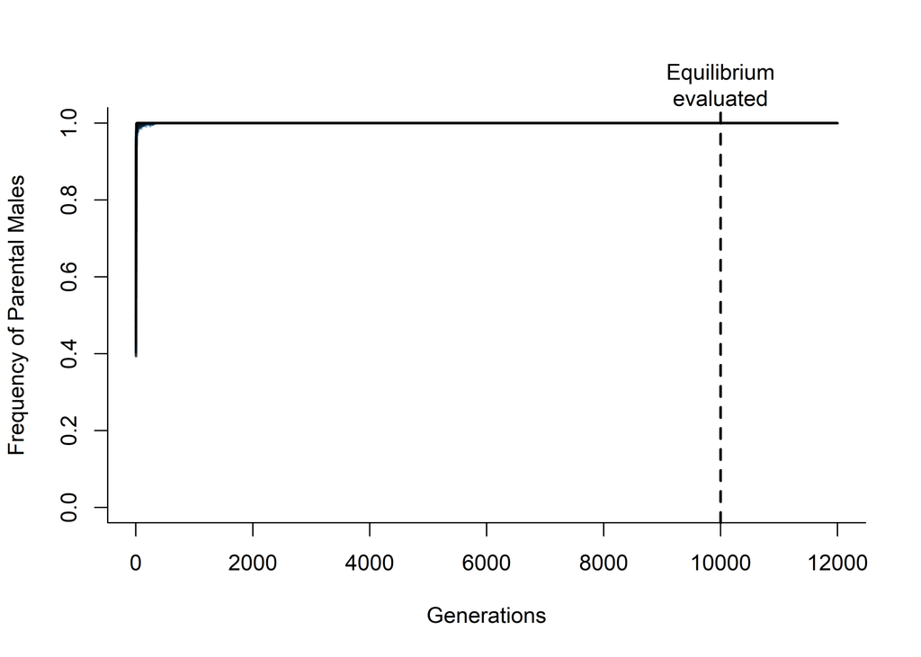

Parent frequencies

Parent Frequncies with heritable female preferences

|  | Generation | ParentFreq | ParentW | NonParentW |
| --- | --- | --- | --- | --- |
| parent-pref-nogenetics_1_summary.txt_1 | 11999 | 1 | 3.47732 | 0 |
| parent-pref-nogenetics_1_summary.txt_2 | 11999 | 1 | 3.51292 | 0 |
| parent-pref-nogenetics_1_summary.txt_3 | 11999 | 1 | 3.52632 | 0 |
| parent-pref-nogenetics_1_summary.txt_4 | 11999 | 1 | 3.56129 | 0 |
| parent-pref-nogenetics_10_summary.txt_1 | 11999 | 1 | 3.56907 | 0 |
| parent-pref-nogenetics_10_summary.txt_2 | 11999 | 1 | 3.41502 | 0 |
| parent-pref-nogenetics_10_summary.txt_3 | 11999 | 1 | 3.59229 | 0 |
| parent-pref-nogenetics_10_summary.txt_4 | 11999 | 1 | 2.93807 | 0 |
| parent-pref-nogenetics_2_summary.txt_1 | 11999 | 1 | 3.38207 | 0 |
| parent-pref-nogenetics_2_summary.txt_2 | 11999 | 1 | 3.58910 | 0 |
| parent-pref-nogenetics_2_summary.txt_3 | 11999 | 1 | 3.54489 | 0 |
| parent-pref-nogenetics_2_summary.txt_4 | 11999 | 1 | 3.46535 | 0 |
| parent-pref-nogenetics_3_summary.txt_1 | 11999 | 1 | 3.62805 | 0 |
| parent-pref-nogenetics_3_summary.txt_2 | 11999 | 1 | 3.56133 | 0 |
| parent-pref-nogenetics_3_summary.txt_3 | 11999 | 1 | 3.56287 | 0 |
| parent-pref-nogenetics_3_summary.txt_4 | 11999 | 1 | 3.34757 | 0 |
| parent-pref-nogenetics_4_summary.txt_1 | 11999 | 1 | 3.51793 | 0 |
| parent-pref-nogenetics_4_summary.txt_2 | 11999 | 1 | 3.48810 | 0 |
| parent-pref-nogenetics_4_summary.txt_3 | 11999 | 1 | 3.22710 | 0 |
| parent-pref-nogenetics_4_summary.txt_4 | 11999 | 1 | 3.55332 | 0 |
| parent-pref-nogenetics_5_summary.txt_1 | 11999 | 1 | 3.47589 | 0 |
| parent-pref-nogenetics_5_summary.txt_2 | 11999 | 1 | 3.58017 | 0 |
| parent-pref-nogenetics_5_summary.txt_3 | 11999 | 1 | 3.44314 | 0 |
| parent-pref-nogenetics_5_summary.txt_4 | 11999 | 1 | 3.49304 | 0 |
| parent-pref-nogenetics_6_summary.txt_1 | 11999 | 1 | 3.42885 | 0 |
| parent-pref-nogenetics_6_summary.txt_2 | 11999 | 1 | 3.39571 | 0 |
| parent-pref-nogenetics_6_summary.txt_3 | 11999 | 1 | 3.52342 | 0 |
| parent-pref-nogenetics_6_summary.txt_4 | 11999 | 1 | 3.57113 | 0 |
| parent-pref-nogenetics_7_summary.txt_1 | 11999 | 1 | 3.20644 | 0 |
| parent-pref-nogenetics_7_summary.txt_2 | 11999 | 1 | 3.56566 | 0 |
| parent-pref-nogenetics_7_summary.txt_3 | 11999 | 1 | 3.53975 | 0 |
| parent-pref-nogenetics_7_summary.txt_4 | 11999 | 1 | 3.61587 | 0 |
| parent-pref-nogenetics_8_summary.txt_1 | 11999 | 1 | 3.58487 | 0 |
| parent-pref-nogenetics_8_summary.txt_2 | 11999 | 1 | 3.62474 | 0 |
| parent-pref-nogenetics_8_summary.txt_3 | 11999 | 1 | 3.42466 | 0 |
| parent-pref-nogenetics_8_summary.txt_4 | 11999 | 1 | 3.31599 | 0 |
| parent-pref-nogenetics_9_summary.txt_1 | 11999 | 1 | 3.39300 | 0 |
| parent-pref-nogenetics_9_summary.txt_2 | 11999 | 1 | 3.56495 | 0 |
| parent-pref-nogenetics_9_summary.txt_3 | 11999 | 1 | 3.33719 | 0 |
| parent-pref-nogenetics_9_summary.txt_4 | 11999 | 1 | 3.52485 | 0 |

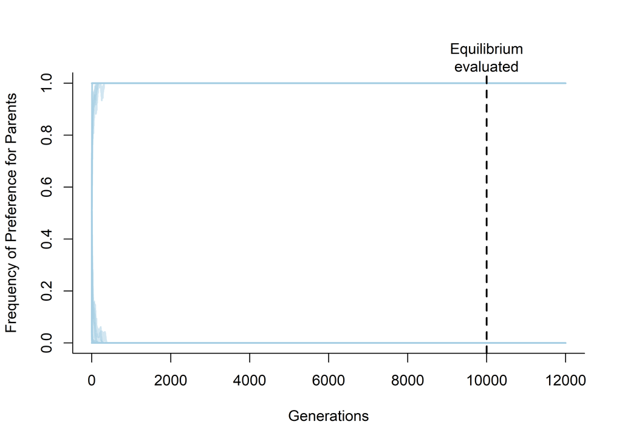

Frequencies of Preferences for Parents when no courtship traits exist

Frequncies of Preference for Parents

|  | Generation | PrefFreq | PrefThresh |
| --- | --- | --- | --- |
| parent-pref-nogenetics_1_summary.txt_1 | 11999 | 0 | -0.1214700 |
| parent-pref-nogenetics_1_summary.txt_2 | 11999 | 0 | -0.1214700 |
| parent-pref-nogenetics_1_summary.txt_3 | 11999 | 0 | -0.1214700 |
| parent-pref-nogenetics_1_summary.txt_4 | 11999 | 0 | -0.1214700 |
| parent-pref-nogenetics_10_summary.txt_1 | 11999 | 0 | 1.0704500 |
| parent-pref-nogenetics_10_summary.txt_2 | 11999 | 0 | 1.0704500 |
| parent-pref-nogenetics_10_summary.txt_3 | 11999 | 0 | 1.0704500 |
| parent-pref-nogenetics_10_summary.txt_4 | 11999 | 0 | 1.0704500 |
| parent-pref-nogenetics_2_summary.txt_1 | 11999 | 0 | 0.9679710 |
| parent-pref-nogenetics_2_summary.txt_2 | 11999 | 0 | 0.9679710 |
| parent-pref-nogenetics_2_summary.txt_3 | 11999 | 0 | 0.9679710 |
| parent-pref-nogenetics_2_summary.txt_4 | 11999 | 0 | 0.9679710 |
| parent-pref-nogenetics_3_summary.txt_1 | 11999 | 1 | -0.8593650 |
| parent-pref-nogenetics_3_summary.txt_2 | 11999 | 1 | -0.8593650 |
| parent-pref-nogenetics_3_summary.txt_3 | 11999 | 1 | -0.8593650 |
| parent-pref-nogenetics_3_summary.txt_4 | 11999 | 1 | -0.8593650 |
| parent-pref-nogenetics_4_summary.txt_1 | 11999 | 0 | -0.0267638 |
| parent-pref-nogenetics_4_summary.txt_2 | 11999 | 0 | -0.0267638 |
| parent-pref-nogenetics_4_summary.txt_3 | 11999 | 0 | -0.0267638 |
| parent-pref-nogenetics_4_summary.txt_4 | 11999 | 0 | -0.0267638 |
| parent-pref-nogenetics_5_summary.txt_1 | 11999 | 0 | 0.1798580 |
| parent-pref-nogenetics_5_summary.txt_2 | 11999 | 0 | 0.1798580 |
| parent-pref-nogenetics_5_summary.txt_3 | 11999 | 0 | 0.1798580 |
| parent-pref-nogenetics_5_summary.txt_4 | 11999 | 0 | 0.1798580 |
| parent-pref-nogenetics_6_summary.txt_1 | 11999 | 1 | 0.5851370 |
| parent-pref-nogenetics_6_summary.txt_2 | 11999 | 1 | 0.5851370 |
| parent-pref-nogenetics_6_summary.txt_3 | 11999 | 1 | 0.5851370 |
| parent-pref-nogenetics_6_summary.txt_4 | 11999 | 1 | 0.5851370 |
| parent-pref-nogenetics_7_summary.txt_1 | 11999 | 0 | -0.0335299 |
| parent-pref-nogenetics_7_summary.txt_2 | 11999 | 0 | -0.0335299 |
| parent-pref-nogenetics_7_summary.txt_3 | 11999 | 0 | -0.0335299 |
| parent-pref-nogenetics_7_summary.txt_4 | 11999 | 0 | -0.0335299 |
| parent-pref-nogenetics_8_summary.txt_1 | 11999 | 0 | -0.6219730 |
| parent-pref-nogenetics_8_summary.txt_2 | 11999 | 0 | -0.6219730 |
| parent-pref-nogenetics_8_summary.txt_3 | 11999 | 0 | -0.6219730 |
| parent-pref-nogenetics_8_summary.txt_4 | 11999 | 0 | -0.6219730 |
| parent-pref-nogenetics_9_summary.txt_1 | 11999 | 1 | 0.3837670 |
| parent-pref-nogenetics_9_summary.txt_2 | 11999 | 1 | 0.3837670 |
| parent-pref-nogenetics_9_summary.txt_3 | 11999 | 1 | 0.3837670 |
| parent-pref-nogenetics_9_summary.txt_4 | 11999 | 1 | 0.3837670 |

Of the 40 populations that survived, 12 were fixed for a preference for parents and 28 were fixed for a preference against parents. 0 maintained variation in female preferences.

### Courthip and Parenting + Heritable Female Preferences

Here, the female preference has unlinked additive genetic variance that is inherited. The traits begin as uncorrelated and are not pleiotropic (i.e., they have different genes underlying them). A threshold is set in the first generation that determines the switch point for when females prefer courters or non-courters. This threshold does not change over the generations. Only non-parental males are sneakers, and when females choose to mate with non-parents, the nest has a 10% survival rate.

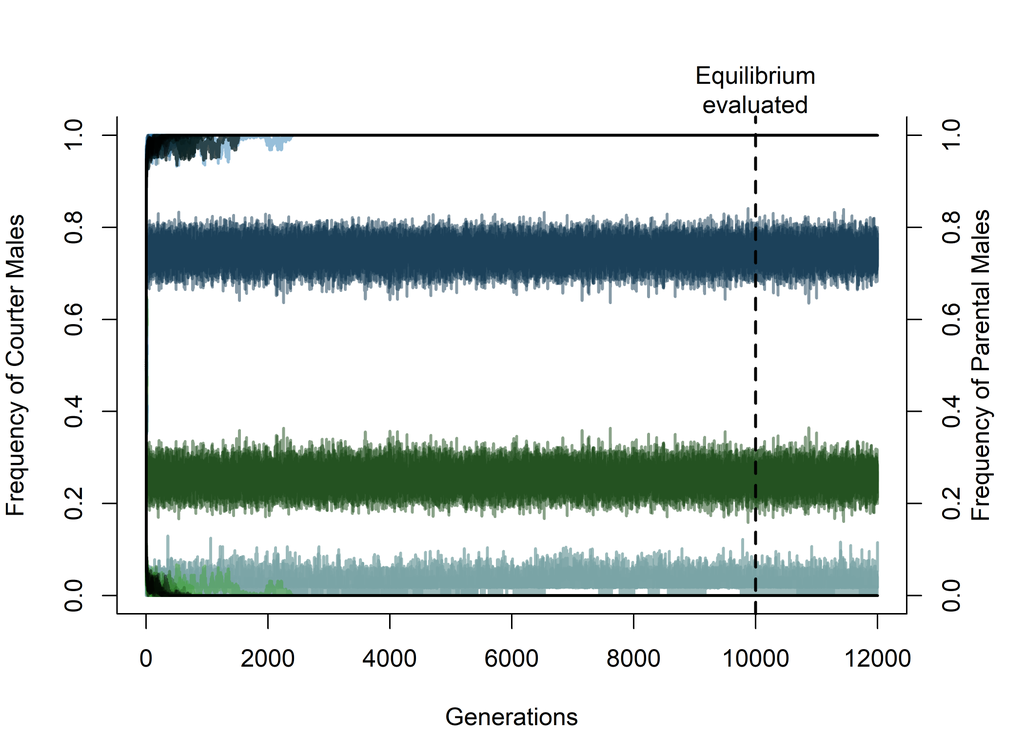

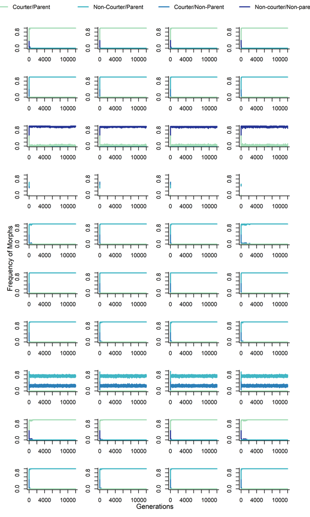

Frequency of four morphs per rep

Morph Frequencies with heritable preferences

|  | Generation | FreqNcNp | FreqCNp | FreqNcP | FreqCP |
| --- | --- | --- | --- | --- | --- |
| parent-courter-pref-nogenetics_1_summary.txt_1 | 11999 | 0.000000 | 0.000000 | 0.000000 | 1.0000000 |
| parent-courter-pref-nogenetics_1_summary.txt_2 | 11999 | 0.000000 | 0.000000 | 0.000000 | 1.0000000 |
| parent-courter-pref-nogenetics_1_summary.txt_3 | 11999 | 0.000000 | 0.000000 | 0.000000 | 1.0000000 |
| parent-courter-pref-nogenetics_1_summary.txt_4 | 11999 | 0.000000 | 0.000000 | 0.000000 | 1.0000000 |
| parent-courter-pref-nogenetics_10_summary.txt_1 | 11999 | 0.000000 | 0.000000 | 1.000000 | 0.0000000 |
| parent-courter-pref-nogenetics_10_summary.txt_2 | 11999 | 0.000000 | 0.000000 | 1.000000 | 0.0000000 |
| parent-courter-pref-nogenetics_10_summary.txt_3 | 11999 | 0.000000 | 0.000000 | 1.000000 | 0.0000000 |
| parent-courter-pref-nogenetics_10_summary.txt_4 | 11999 | 0.000000 | 0.000000 | 1.000000 | 0.0000000 |
| parent-courter-pref-nogenetics_2_summary.txt_1 | 11999 | 1.000000 | 0.000000 | 0.000000 | 0.0000000 |
| parent-courter-pref-nogenetics_2_summary.txt_2 | 11999 | 0.978723 | 0.000000 | 0.000000 | 0.0212766 |
| parent-courter-pref-nogenetics_2_summary.txt_3 | 11999 | 0.981481 | 0.000000 | 0.000000 | 0.0185185 |
| parent-courter-pref-nogenetics_2_summary.txt_4 | 11999 | 0.946429 | 0.000000 | 0.000000 | 0.0535714 |
| parent-courter-pref-nogenetics_3_summary.txt_1 | 17 | 0.000000 | 0.357143 | 0.642857 | 0.0000000 |
| parent-courter-pref-nogenetics_3_summary.txt_2 | 17 | 0.000000 | 0.589286 | 0.410714 | 0.0000000 |
| parent-courter-pref-nogenetics_3_summary.txt_3 | 17 | 0.000000 | 0.586957 | 0.413043 | 0.0000000 |
| parent-courter-pref-nogenetics_3_summary.txt_4 | 17 | 0.000000 | 0.456140 | 0.543860 | 0.0000000 |
| parent-courter-pref-nogenetics_4_summary.txt_1 | 11999 | 0.000000 | 0.000000 | 1.000000 | 0.0000000 |
| parent-courter-pref-nogenetics_4_summary.txt_2 | 11999 | 0.000000 | 0.000000 | 1.000000 | 0.0000000 |
| parent-courter-pref-nogenetics_4_summary.txt_3 | 11999 | 0.000000 | 0.000000 | 1.000000 | 0.0000000 |
| parent-courter-pref-nogenetics_4_summary.txt_4 | 11999 | 0.000000 | 0.000000 | 1.000000 | 0.0000000 |
| parent-courter-pref-nogenetics_5_summary.txt_1 | 11999 | 0.000000 | 0.000000 | 1.000000 | 0.0000000 |
| parent-courter-pref-nogenetics_5_summary.txt_2 | 11999 | 0.000000 | 0.000000 | 1.000000 | 0.0000000 |
| parent-courter-pref-nogenetics_5_summary.txt_3 | 11999 | 0.000000 | 0.000000 | 1.000000 | 0.0000000 |
| parent-courter-pref-nogenetics_5_summary.txt_4 | 11999 | 0.000000 | 0.000000 | 1.000000 | 0.0000000 |
| parent-courter-pref-nogenetics_6_summary.txt_1 | 11999 | 0.000000 | 0.000000 | 1.000000 | 0.0000000 |
| parent-courter-pref-nogenetics_6_summary.txt_2 | 11999 | 0.000000 | 0.000000 | 1.000000 | 0.0000000 |
| parent-courter-pref-nogenetics_6_summary.txt_3 | 11999 | 0.000000 | 0.000000 | 1.000000 | 0.0000000 |
| parent-courter-pref-nogenetics_6_summary.txt_4 | 11999 | 0.000000 | 0.000000 | 1.000000 | 0.0000000 |
| parent-courter-pref-nogenetics_7_summary.txt_1 | 11999 | 0.000000 | 0.248634 | 0.751366 | 0.0000000 |
| parent-courter-pref-nogenetics_7_summary.txt_2 | 11999 | 0.000000 | 0.214085 | 0.785915 | 0.0000000 |
| parent-courter-pref-nogenetics_7_summary.txt_3 | 11999 | 0.000000 | 0.250000 | 0.750000 | 0.0000000 |
| parent-courter-pref-nogenetics_7_summary.txt_4 | 11999 | 0.000000 | 0.210736 | 0.789264 | 0.0000000 |
| parent-courter-pref-nogenetics_8_summary.txt_1 | 11999 | 0.000000 | 0.000000 | 0.000000 | 1.0000000 |
| parent-courter-pref-nogenetics_8_summary.txt_2 | 11999 | 0.000000 | 0.000000 | 0.000000 | 1.0000000 |
| parent-courter-pref-nogenetics_8_summary.txt_3 | 11999 | 0.000000 | 0.000000 | 0.000000 | 1.0000000 |
| parent-courter-pref-nogenetics_8_summary.txt_4 | 11999 | 0.000000 | 0.000000 | 0.000000 | 1.0000000 |
| parent-courter-pref-nogenetics_9_summary.txt_1 | 11999 | 0.000000 | 0.000000 | 1.000000 | 0.0000000 |
| parent-courter-pref-nogenetics_9_summary.txt_2 | 11999 | 0.000000 | 0.000000 | 1.000000 | 0.0000000 |
| parent-courter-pref-nogenetics_9_summary.txt_3 | 11999 | 0.000000 | 0.000000 | 1.000000 | 0.0000000 |
| parent-courter-pref-nogenetics_9_summary.txt_4 | 11999 | 0.000000 | 0.000000 | 1.000000 | 0.0000000 |

Again, evolving preferences maintain variation in 11 of the 40. 4 of the 40 populations crashed, though.

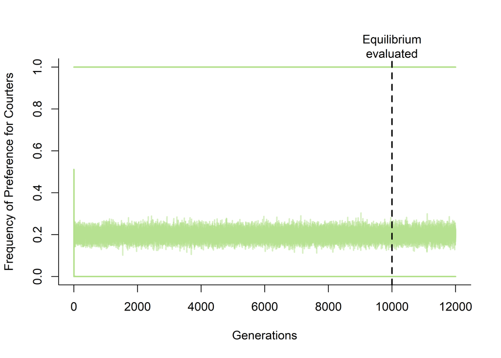

Frequency of Preference of Courters with both parents and courters in the population

Frequncies of Preference for Courters

|  | Generation | PrefFreq | PrefThresh |
| --- | --- | --- | --- |
| parent-courter-pref-nogenetics_1_summary.txt_1 | 11999 | 1.000000 | -1.3979600 |
| parent-courter-pref-nogenetics_1_summary.txt_2 | 11999 | 1.000000 | -1.3979600 |
| parent-courter-pref-nogenetics_1_summary.txt_3 | 11999 | 1.000000 | -1.3979600 |
| parent-courter-pref-nogenetics_1_summary.txt_4 | 11999 | 1.000000 | -1.3979600 |
| parent-courter-pref-nogenetics_10_summary.txt_1 | 11999 | 0.000000 | 0.2257900 |
| parent-courter-pref-nogenetics_10_summary.txt_2 | 11999 | 0.000000 | 0.2257900 |
| parent-courter-pref-nogenetics_10_summary.txt_3 | 11999 | 0.000000 | 0.2257900 |
| parent-courter-pref-nogenetics_10_summary.txt_4 | 11999 | 0.000000 | 0.2257900 |
| parent-courter-pref-nogenetics_2_summary.txt_1 | 11999 | 0.000000 | 0.5148780 |
| parent-courter-pref-nogenetics_2_summary.txt_2 | 11999 | 0.000000 | 0.5148780 |
| parent-courter-pref-nogenetics_2_summary.txt_3 | 11999 | 0.000000 | 0.5148780 |
| parent-courter-pref-nogenetics_2_summary.txt_4 | 11999 | 0.000000 | 0.5148780 |
| parent-courter-pref-nogenetics_3_summary.txt_1 | 17 | 1.000000 | -0.5078970 |
| parent-courter-pref-nogenetics_3_summary.txt_2 | 17 | 1.000000 | -0.5078970 |
| parent-courter-pref-nogenetics_3_summary.txt_3 | 17 | 1.000000 | -0.5078970 |
| parent-courter-pref-nogenetics_3_summary.txt_4 | 17 | 1.000000 | -0.5078970 |
| parent-courter-pref-nogenetics_4_summary.txt_1 | 11999 | 0.000000 | 0.4129600 |
| parent-courter-pref-nogenetics_4_summary.txt_2 | 11999 | 0.000000 | 0.4129600 |
| parent-courter-pref-nogenetics_4_summary.txt_3 | 11999 | 0.000000 | 0.4129600 |
| parent-courter-pref-nogenetics_4_summary.txt_4 | 11999 | 0.000000 | 0.4129600 |
| parent-courter-pref-nogenetics_5_summary.txt_1 | 11999 | 0.000000 | -0.6069470 |
| parent-courter-pref-nogenetics_5_summary.txt_2 | 11999 | 0.000000 | -0.6069470 |
| parent-courter-pref-nogenetics_5_summary.txt_3 | 11999 | 0.000000 | -0.6069470 |
| parent-courter-pref-nogenetics_5_summary.txt_4 | 11999 | 0.000000 | -0.6069470 |
| parent-courter-pref-nogenetics_6_summary.txt_1 | 11999 | 0.000000 | 0.0460271 |
| parent-courter-pref-nogenetics_6_summary.txt_2 | 11999 | 0.000000 | 0.0460271 |
| parent-courter-pref-nogenetics_6_summary.txt_3 | 11999 | 0.000000 | 0.0460271 |
| parent-courter-pref-nogenetics_6_summary.txt_4 | 11999 | 0.000000 | 0.0460271 |
| parent-courter-pref-nogenetics_7_summary.txt_1 | 11999 | 0.216802 | 1.3614400 |
| parent-courter-pref-nogenetics_7_summary.txt_2 | 11999 | 0.185915 | 1.3614400 |
| parent-courter-pref-nogenetics_7_summary.txt_3 | 11999 | 0.168044 | 1.3614400 |
| parent-courter-pref-nogenetics_7_summary.txt_4 | 11999 | 0.223340 | 1.3614400 |
| parent-courter-pref-nogenetics_8_summary.txt_1 | 11999 | 1.000000 | 0.2216090 |
| parent-courter-pref-nogenetics_8_summary.txt_2 | 11999 | 1.000000 | 0.2216090 |
| parent-courter-pref-nogenetics_8_summary.txt_3 | 11999 | 1.000000 | 0.2216090 |
| parent-courter-pref-nogenetics_8_summary.txt_4 | 11999 | 1.000000 | 0.2216090 |
| parent-courter-pref-nogenetics_9_summary.txt_1 | 11999 | 0.000000 | 0.6873330 |
| parent-courter-pref-nogenetics_9_summary.txt_2 | 11999 | 0.000000 | 0.6873330 |
| parent-courter-pref-nogenetics_9_summary.txt_3 | 11999 | 0.000000 | 0.6873330 |
| parent-courter-pref-nogenetics_9_summary.txt_4 | 11999 | 0.000000 | 0.6873330 |

Of the 36 populations that survived, 8 were fixed for a preference for courters and 24 were fixed for a preference against courters. 4 maintained variation in female preferences.